# Polygenic models of gene expression levels in GAIT2. Round 1.

Andrey Ziyatdinov

2015-10-05

# Protocol

1. Read gene expression traits from `Gait2_31082015_genes.raw.scaled.filter.rank` file.
2. Run polygenic model using SOLAR and solarius.
   - `eDateNum` and `eGCMean` covariates are fixed.
   - `AGE` and `SEX` covariates are screened at `0.1` (marginal) significance level.
   - `c2` house-hold effect is screened according to the default SOLAR [rules](http://ugcd.github.io/solarius/vignettes/tutorial.html#polygenic-model-in-solar).
3. Discard models with certain problems.
   - Returned an error in `solarius` (`12` models).
   - Computed by `solarius`, but with an error by SOLAR pointed by `solar.ok` value (`3` models).
   - Computed models, but with a high kurtosis level, greater than `1.5` (`65` models).

## Material

Input data:

- `/home/datasets/GAIT2/Expression/Gait2_31082015/Gait2_31082015_genes.raw.scaled.filter.rank` file on `bioinf02` server at Sant Pau.

Scripts available on GAIT2 private repository on GitHub:

- 01-run-poly-genes.R script to run the analysis.
- 01-poly-expr.Rmd script to produce this report.

Output results:

- In a secret folder at DropBox.

## TODO

- Correct the instrumental noise in a different way by a univariate/multivariate method, such a way that it would be not necessary to include `eDateNum` and `eGCMean` covariates in regression models.
- Replace the way SOLAR defines whether to retain `c2` house-hold effect (a random effect with `0.01` of variance is to be removed).
- Estimate the SEX-specific heritability for the gene expression traits.

# Results in brief

A brief version of results is similar to that in (Emilsson et al. 2008):

- table with the number of *heritable* gene expression traits according to a selected FDR threshold (see Emilsson et al. 2008, Table 1);
- histogram of heritability estimate at 0.05 FDR (see Emilsson et al. 2008, Supplementary Figure 2 (c)).

The R code to compute FDR correction is based on function [p.adjust](https://stat.ethz.ch/R-manual/R-devel/library/stats/html/p.adjust.html):

```
p.adjust(pval, method = "fdr") <= alpha
```

| FDR | num | total | perc |
| --- | --- | --- | --- |
| 0.05 | 16,363 | 17,941 | 91.2% |
| 0.01 | 15,405 | 17,941 | 85.86% |
| 0.001 | 13,955 | 17,941 | 77.78% |

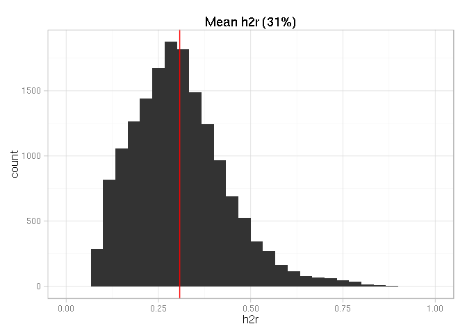

# Results in more detail

*Note*: Results presented below are extracted for the heritable expression traits only (at `0.05` FDR significance level).

A polygenic model of SOLAR reports other output parameters than `h2r`. One can see below the summary of the model corresponding to the first gene expression trait.

```
Call: solarPolygenic(data = as.data.frame(edat), traits = "expr", covlist = c(covlist.fixed,
    covlist.test), covtest = TRUE)

File polygenic.out:
    Pedigree:    dat.ped
    Phenotypes:  dat.phe
    Trait:       expr                  Individuals:  916

             H2r is 0.3515963  p = 6.719066e-12  (Significant)
           H2r Std. Error:  0.0624263

              C2 is 0.1065068  p = 0.0093995  (Significant)
            C2 Std. Error:  0.0478243

                                 eDateNum  p = 0.3813424  (Not Sig., but fixed)
                                  eGCMean  p = 1.0734619e-44  (Significant)
                                      AGE  p = 3.3571283e-06  (Significant)
                                      SEX  p = 0.0000445  (Significant)

    35 pedigrees merged into 34 pedigree-household groups

    Proportion of Variance Due to All Final Covariates Is
                  0.2053575

    Loglikelihoods and chi's are in expr/polygenic.logs.out
    Best model is named housepoly and null0
    Final models are named housepoly, house, poly, spor, nocovar
    Initial sporadic and polygenic models are s0 and p0
    Initial household and household polygenic models are h0 and hp0
    Constrained covariate models are named no<covariate name>

    Residual Kurtosis is -0.1362, within normal range
```

R package solarius allows to easily extract the most of the output from SOLAR models.

## Covariates

The models have different sets of covariates, because of screening applied to `AGE` and `SEX`.

| covlist | num | total | perc |
| --- | --- | --- | --- |
| eDateNum, eGCMean, AGE, SEX | 8,277 | 16,363 | 50.58% |
| eDateNum, eGCMean, AGE | 5,017 | 16,363 | 30.66% |
| eDateNum, eGCMean, SEX | 1,961 | 16,363 | 11.98% |
| eDateNum, eGCMean | 1,108 | 16,363 | 6.77% |

## Variance due to covariates

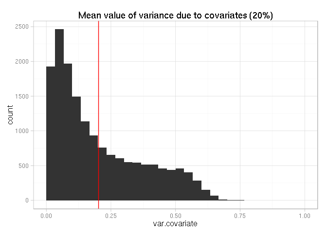

In further analyses, it would be interesting to see the effect of only experimental variables (`eDateNum` and `eGCMean`) in terms of explained variance.

### A model without estimated variance

```
Call: solarPolygenic(data = as.data.frame(edat), traits = "expr", covlist = c(covlist.fixed,
    covlist.test), covtest = TRUE)

File polygenic.out:
    Pedigree:    dat.ped
    Phenotypes:  dat.phe
    Trait:       expr                  Individuals:  916

             H2r is 0.7600803  p = 2.5834837e-31  (Significant)
           H2r Std. Error:  0.0547106

              C2 is 0.0035725  p = 0.4596282  (Not Significant)
            C2 Std. Error:  0.0353151      (C2 retained because nonzero)

                                 eDateNum  p = 0.8450020  (Not Sig., but fixed)
                                  eGCMean  p = 0.7913746  (Not Sig., but fixed)
                                      SEX  p = 0.0230852  (Significant)

    35 pedigrees merged into 34 pedigree-household groups

    Proportion of Variance Due to All Final Covariates Is
        [Not Estimable due to Instability]
        [Some covariate effects may be relatively small]
        [Consider running fewer covariates or 'bayesavg -cov']

    Loglikelihoods and chi's are in expr/polygenic.logs.out
    Best model is named housepoly and null0
    Final models are named housepoly, house, poly, spor, nocovar
    Initial sporadic and polygenic models are s0 and p0
    Initial household and household polygenic models are h0 and hp0
    Constrained covariate models are named no<covariate name>

    Residual Kurtosis is -0.1011, within normal range
```

## Household effect

| model | num | total | perc |
| --- | --- | --- | --- |
| c2.zero | 3,248 | 16,363 | 19.85% |
| c2.nonzero | 13,115 | 16,363 | 80.15% |
| c2.greater.0.05 | 7,207 | 16,363 | 44.04% |
| c2.lower.0.01 | 4,279 | 16,363 | 26.15% |

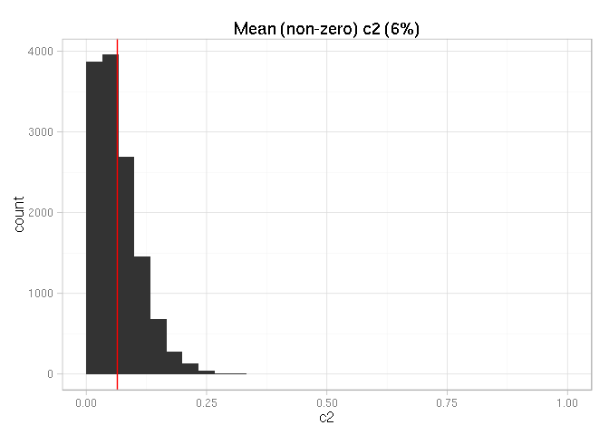

## Residual kurtosis

Although the gene expression traits were transformed according to rank-based transformation (informal), one can plot the actual values of residual kurtosis of the models. Note that the critical value of residual kurtosis posed by SOLAR is `0.8`.

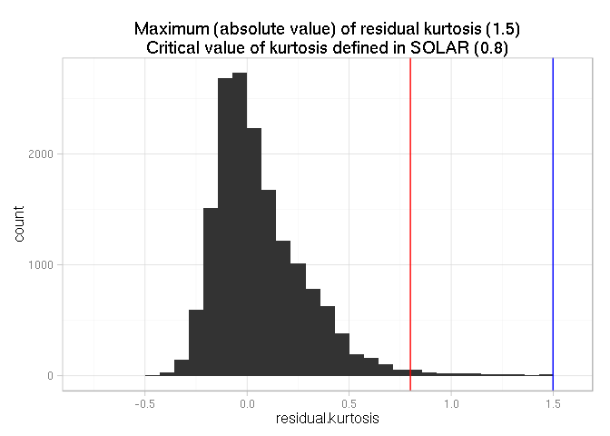

References

Emilsson, Valur, Gudmar Thorleifsson, Bin Zhang, Amy S Leonardson, Florian Zink, Jun Zhu, Sonia Carlson, et al. 2008. “Genetics of Gene Expression and Its Effect on Disease.” *Nature* 452 (7186). Nature Publishing Group: 423–28.